# Instacart_EDA_MBA

Tom Vanichachiva

March 4, 2021

# Instacart Exploratory Data Analysis and Market Basket Analysis

In this analysis I will explore transactional Instacart data provided by Kaggle.

Kaggle is a data science and machine learning platform that allows users to compete and collaborate on data science competitions.

The datasets in this competition were too large to push to GitHub. The datasets can be found here: https://www.kaggle.com/c/instacart-market-basket-analysis/data

## Loading Libraries

```r
library(dplyr)
library(tidyr)
library(ggplot2)
library(arules)
library(cowplot)
library(scales)
library(arules)
library(arulesViz)
```

## Load in datasets

```r
aisles <- read.csv("data/aisles.csv")
department <- read.csv("data/departments.csv")
products_prior <- read.csv("data/order_products__prior.csv")
products_train <- read.csv("data/order_products__train.csv")
orders <- read.csv("data/orders.csv")
products <- read.csv("data/products.csv")
```

## Inspect the data

The Aisle dataset provides category information for products The Category dataset also provides additional cateogry information for products The Products Prior/Test datasets provide information on details of each transaction The Orders dataset provides data on order metadata such as what time of day the order was placed The Products dataset provides information on product metadata such as the name of the product

```r
glimpse(aisles)
```

```
## Rows: 134
## Columns: 2
## $ aisle_id <int> 1, 2, 3, 4, 5, 6, 7, 8, 9, 10, 11, 12, 13, 14, 15, 16, 17,...
## $ aisle    <chr> "prepared soups salads", "specialty cheeses", "energy gran...
```

```r
glimpse(department)
```

```
## Rows: 21
## Columns: 2
## $ department_id <int> 1, 2, 3, 4, 5, 6, 7, 8, 9, 10, 11, 12, 13, 14, 15, 16...
## $ department    <chr> "frozen", "other", "bakery", "produce", "alcohol", "i...
```

```r
glimpse(products_prior)
```

```
## Rows: 32,434,489
## Columns: 4
## $ order_id          <int> 2, 2, 2, 2, 2, 2, 2, 2, 2, 3, 3, 3, 3, 3, 3, 3, 3...
## $ product_id        <int> 33120, 28985, 9327, 45918, 30035, 17794, 40141, 1...
## $ add_to_cart_order <int> 1, 2, 3, 4, 5, 6, 7, 8, 9, 1, 2, 3, 4, 5, 6, 7, 8...
## $ reordered         <int> 1, 1, 0, 1, 0, 1, 1, 1, 0, 1, 1, 1, 1, 1, 1, 1, 1...
```

```r
glimpse(products_train)
```

```
## Rows: 1,384,617
## Columns: 4
## $ order_id          <int> 1, 1, 1, 1, 1, 1, 1, 1, 36, 36, 36, 36, 36, 36, 3...
## $ product_id        <int> 49302, 11109, 10246, 49683, 43633, 13176, 47209, ...
## $ add_to_cart_order <int> 1, 2, 3, 4, 5, 6, 7, 8, 1, 2, 3, 4, 5, 6, 7, 8, 1...
## $ reordered         <int> 1, 1, 0, 0, 1, 0, 0, 1, 0, 1, 0, 1, 1, 1, 1, 1, 0...
```

```r
glimpse(orders)
```

```
## Rows: 3,421,083
## Columns: 7
## $ order_id               <int> 2539329, 2398795, 473747, 2254736, 431534, 3...
## $ user_id                <int> 1, 1, 1, 1, 1, 1, 1, 1, 1, 1, 1, 2, 2, 2, 2,...
## $ eval_set               <chr> "prior", "prior", "prior", "prior", "prior",...
## $ order_number           <int> 1, 2, 3, 4, 5, 6, 7, 8, 9, 10, 11, 1, 2, 3, ...
## $ order_dow              <int> 2, 3, 3, 4, 4, 2, 1, 1, 1, 4, 4, 2, 5, 1, 2,...
## $ order_hour_of_day      <int> 8, 7, 12, 7, 15, 7, 9, 14, 16, 8, 8, 11, 10,...
## $ days_since_prior_order <dbl> NA, 15, 21, 29, 28, 19, 20, 14, 0, 30, 14, N...
```

```r
glimpse(products)
```

```
## Rows: 49,688
## Columns: 4
## $ product_id    <int> 1, 2, 3, 4, 5, 6, 7, 8, 9, 10, 11, 12, 13, 14, 15, 16...
## $ product_name  <chr> "Chocolate Sandwich Cookies", "All-Seasons Salt", "Ro...
## $ aisle_id      <int> 61, 104, 94, 38, 5, 11, 98, 116, 120, 115, 31, 119, 1...
## $ department_id <int> 19, 13, 7, 1, 13, 11, 7, 1, 16, 7, 7, 1, 11, 17, 18, ...
```

## Convert character variables to factors

Converting a variable to a factor is a way for R to recognize a variable as a categorical variable. This will come in useful when we need to plot categorical variables.

```r
aisles <- aisles %>%
            mutate(aisle = as.factor(aisle))

department <-  department %>%
                mutate(department = as.factor(department))

orders <-  orders %>%
            mutate(eval_set = as.factor(eval_set)
                   ,order_hour_of_day = as.numeric(order_hour_of_day)
                   ,order_dow = as.factor(order_dow)
                   ,order_hour_of_day = as.factor(order_hour_of_day))

products <- products %>%
              mutate(product_name = as.factor(product_name))
```

## Top 10 Most Ordered Items

In both the prior/train datasets it looks like bananas and organic bananas are the most ordered items.

These plots will compare side by side to see how different the prior dataset is from the train dataset.

```r
top10_products_prior <- products_prior %>%
                        group_by(product_id) %>%
                        summarise(number_of_orders = n()) %>%
                        top_n(10) %>%
                        left_join(products, by = "product_id") %>%
                        select(product_name, number_of_orders) %>%
                        arrange(desc(number_of_orders))
top10_products_train <- products_train %>%
                        group_by(product_id) %>%
                        summarise(number_of_orders = n()) %>%
                        top_n(10) %>%
                        left_join(products, by = "product_id") %>%
                        select(product_name, number_of_orders) %>%
                        arrange(desc(number_of_orders))
```

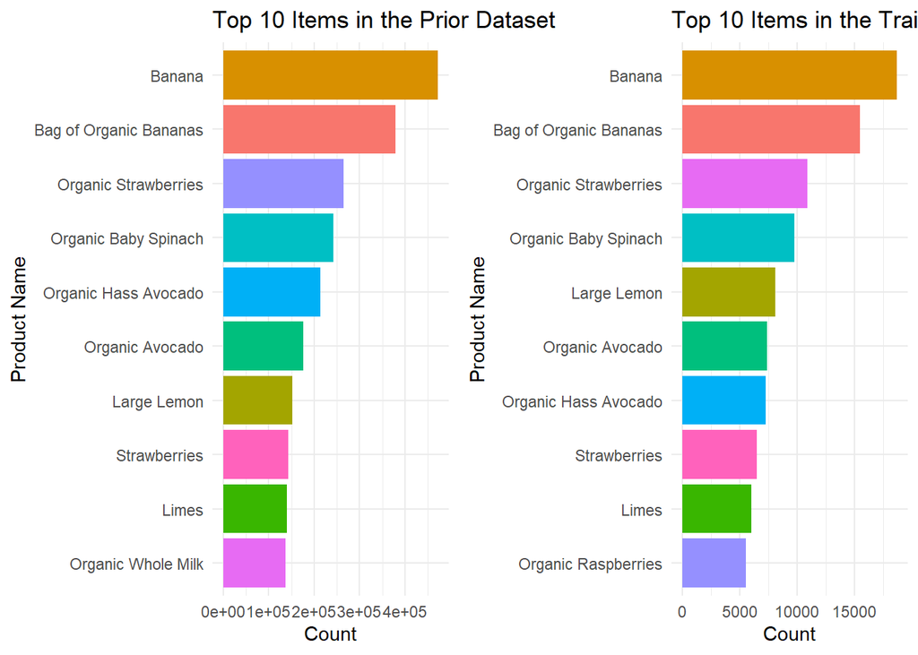

```r
prod_bar_plot <- function(ds) {
  ds %>%
    ggplot(aes(reorder(product_name, number_of_orders), number_of_orders, fill = product_name)) +
    geom_bar(stat = "identity") +
    coord_flip() +
    labs(x = "Product Name", y = "Count") +
    theme_minimal()  +
    theme(legend.position = "none")

}

prod_prior_plt <- prod_bar_plot(top10_products_prior)
prod_train_plt <- prod_bar_plot(top10_products_train)


plot_grid(prod_prior_plt + labs(title = "Top 10 Items in the Prior Dataset")
          ,prod_train_plt + labs(title =  "Top 10 Items in the Train Dataset"))
```

## Average Instacart Basket Size - Train/Prior

The average basket size peaks around 5 items per transaction. This might signify that most people using Instacart are not doing all of their shopping on Instacart, rather they are using Instacart to pick up a few items.

The distribution is positively skewed (right skewed). If these datasets were recreated in 2020, the distribution would probably be more negatively skewed (left skewed), i.e. the average basket size is probably larger.

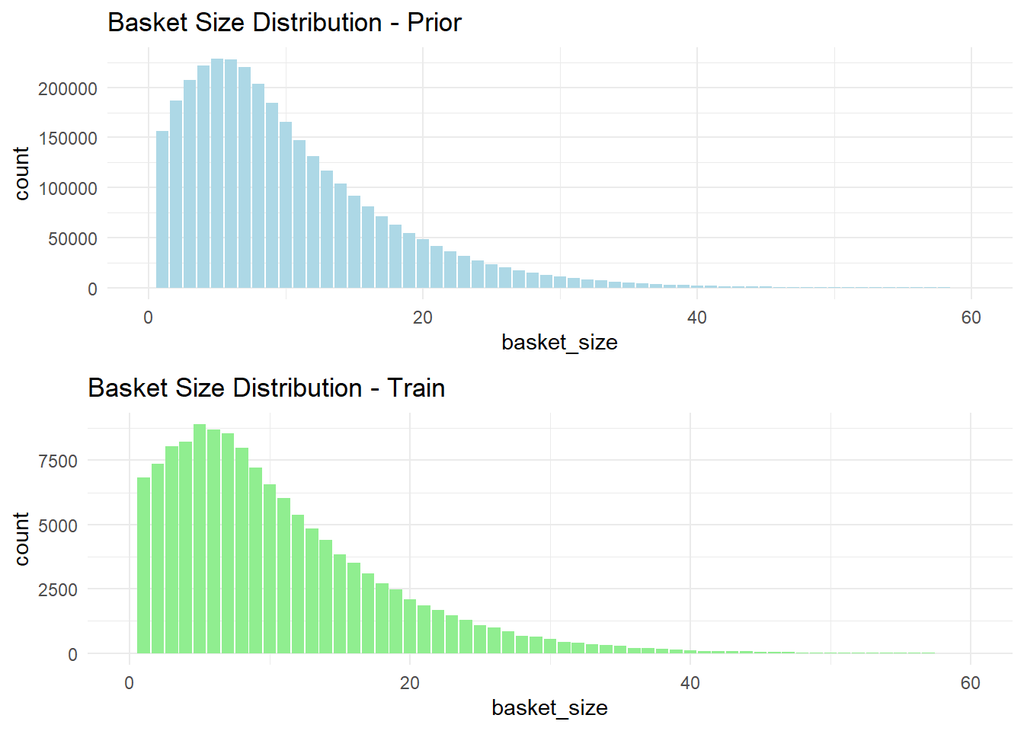

```r
basket_size_prior <- products_prior %>%
                      group_by(order_id) %>%
                      summarise(basket_size = last(add_to_cart_order)) %>%
                      ggplot(aes(basket_size)) +
                      geom_histogram(stat = "count", fill = "light blue", binwidth = 5) +
                      xlim(0,60) +
                      #scale_x_continuous(breaks = seq(from = 0, to = 60, by = 5)) +
                      theme_minimal()
basket_size_train <- products_train %>%
                      group_by(order_id) %>%
                      summarise(basket_size = last(add_to_cart_order)) %>%
                      ggplot(aes(basket_size)) +
                      geom_histogram(stat = "count", fill = "light green") +
                      xlim(0,60) +
                      #scale_x_continuous(breaks = seq(from = 0, to = 60, by = 5)) +
                      theme_minimal()
plot_grid(basket_size_prior + labs(title = "Basket Size Distribution - Prior")
          ,basket_size_train + labs(title = "Basket Size Distribution - Train")
          ,ncol = 1)
```

## Busiest Day of the Week

The busiest day of the week seems to be the day 0 and 1. One can assume this is Saturday/Sunday since this is when people typically get their groceries. There is no way to definitively determine this.

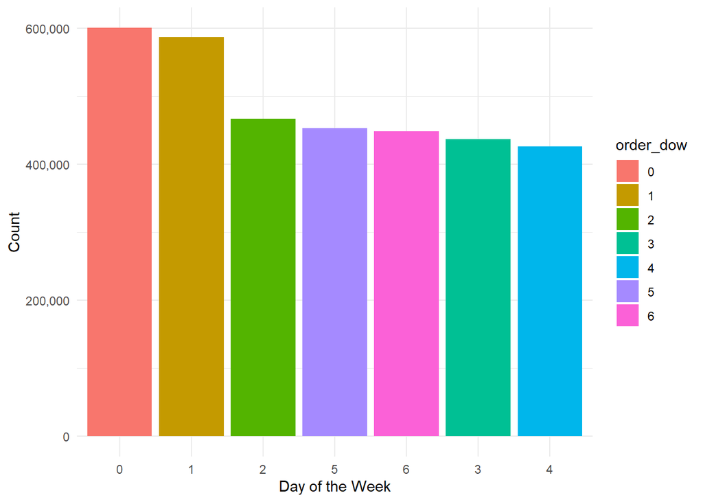

```r
orders %>%
  group_by(order_dow) %>%
  tally() %>%
  arrange(desc(n)) %>%
  ggplot(aes(reorder(order_dow, -n), n, fill = order_dow)) +
    geom_bar(stat = "identity") +
    scale_y_continuous(labels =  comma) +
  labs(x = "Day of the Week", y = "Count") +
    theme_minimal()
```

## Busiest Time of Day

The busiest time of day, i.e. when the most orders are placed, occur in the late morning to early afternoon.

Sending push notifications to Instacart users during this time frame would be the most optimal since this is when users typically place orders.

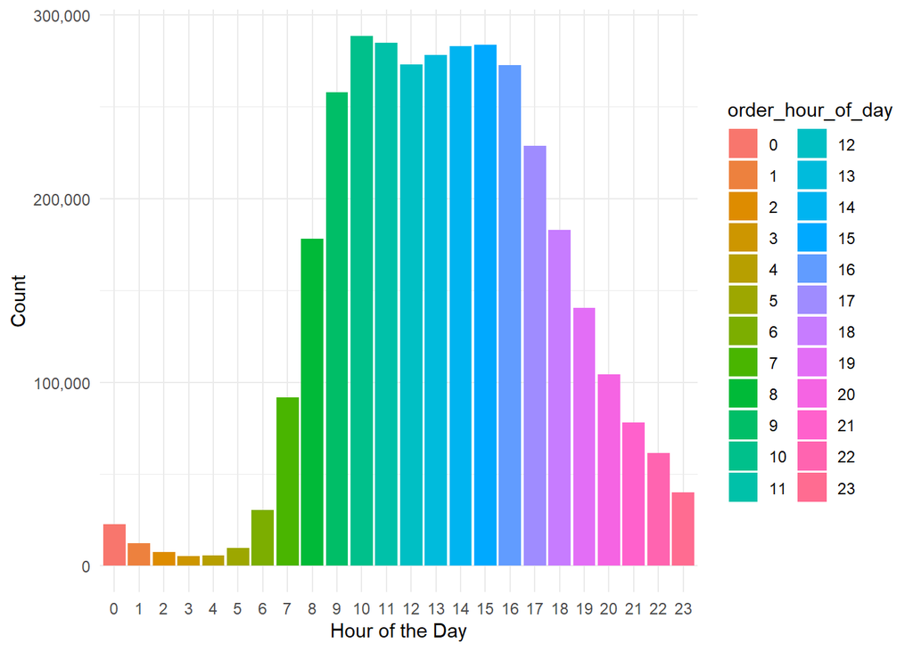

```r
orders %>%
  group_by(order_hour_of_day) %>%
  tally() %>%
  arrange(desc(n)) %>%
  ggplot(aes(order_hour_of_day, n, fill = order_hour_of_day)) +
  geom_bar(stat = "identity") +
  scale_y_continuous(labels =  comma) +
  labs(x = "Hour of the Day", y = "Count") +
  theme_minimal()
```

## Put Data into Basket Format

Putting data into a basket format means there is 1 record per order and all of the products on the order are also on the one record.

For example, in the original data set there could be 3 records for order 1. Each record is a different item. This step will take those 3 records for order 1 and combine it into 1 record.

This step is required for the Apriori Algorithim to read in the Instacart transaction data.

```r
train_basket <- products_train %>%
                    left_join(products, by = "product_id") %>%
                    select(order_id, product_name)

#Write basket data to a transaction file then read it in
write.csv(train_basket, file = "data/train_basket.csv")
baskets <- read.transactions("data/train_basket.csv", format = "single", sep = ",", cols = c(2,3))
summary(baskets)
```

[output not shown]

## Inspecting the First Five Baskets

```r
#Inspecting the first 5 baskets
inspect(baskets[1:5])
```

```
##     items                                                transactionID
## [1] {Bag of Organic Bananas,
##      Bulgarian Yogurt,
##      Cucumber Kirby,
##      Lightly Smoked Sardines in Olive Oil,
##      Organic 4% Milk Fat Whole Milk Cottage Cheese,
##      Organic Celery Hearts,
##      Organic Hass Avocado,
##      Organic Whole String Cheese}                              1
## [2] {Corn Tortillas,
##      Extra Virgin Olive Oil,
##      Gala Apples,
##      Garnet Sweet Potato (Yam),
##      Ground Cumin,
##      I Heart Baby Kale,
##      No Salt Added Black Beans,
##      Organic Baby Carrots,
##      Organic Baby Spinach,
##      Organic Yellow Onion,
##      Original Hummus,
##      Snack Sticks Chicken & Rice Recipe Dog Treats,
##      Total 2% All Natural Plain Greek Yogurt,
##      Unscented Long Lasting Stick Deodorant,
##      Wheat Sandwich Thins}                                     100000
## [3] {Daily Moisture Shampoo,
##      DeTox Caffeine Free Organic Herbal Tea Bags,
##      Ensure Plus Milk Chocolate Nutrition Shake,
##      G Series Perform Frost Glacier Cherry Sports Drink,
##      Original No Pulp 100% Florida Orange Juice,
##      Triple Chocolate Ripple,
##      ZzzQuil Liquid Warming Berry Flavor Sleep-Aid}            1000008
## [4] {Almond Chia Granola Clusters,
##      Boneless Skinless Chicken Breasts,
##      Broccoli Crown,
##      Fresh Cauliflower,
##      Orange Bell Pepper,
##      Organic Gala Apples,
##      Organic Red Onion,
##      Veggie Chips}                                             1000029
## [5] {Cereal,
##      Organic Salted Butter}                                    100003
```

## Establishing Association Rules

```r
basket_rules <- apriori(baskets, parameter = list(support = 0.005, confidence = 0.30))
summary(basket_rules)
```

```r
summary(basket_rules)
```

```
## set of 13 rules
##
## rule length distribution (lhs + rhs):sizes
##  2  3
## 12  1
##
##    Min. 1st Qu.  Median    Mean 3rd Qu.    Max.
##   2.000   2.000   2.000   2.077   2.000   3.000
##
## summary of quality measures:
##     support           confidence        coverage            lift
##  Min.   :0.005236   Min.   :0.3011   Min.   :0.01173   Min.   :2.158
##  1st Qu.:0.005525   1st Qu.:0.3079   1st Qu.:0.01770   1st Qu.:2.429
##  Median :0.007416   Median :0.3210   Median :0.02235   Median :2.603
##  Mean   :0.008710   Mean   :0.3367   Mean   :0.02640   Mean   :2.750
##  3rd Qu.:0.009382   3rd Qu.:0.3467   3rd Qu.:0.02706   3rd Qu.:2.853
##  Max.   :0.018444   Max.   :0.4613   Max.   :0.05558   Max.   :3.910
##      count
##  Min.   : 687
##  1st Qu.: 725
##  Median : 973
##  Mean   :1143
##  3rd Qu.:1231
##  Max.   :2420
##
## mining info:
##     data ntransactions support confidence
##  baskets        131210   0.005        0.3
```

```r
inspect(basket_rules[1:5])
```

```
##     lhs                                       rhs                          support confidence   coverage     lift count
## [1] {Organic Navel Orange}                 => {Bag of Organic Bananas} 0.005525493  0.3661616 0.01509031 3.103622   725
## [2] {Blueberries}                          => {Banana}                 0.005456901  0.3082221 0.01770444 2.159662   716
## [3] {Apple Honeycrisp Organic}             => {Bag of Organic Bananas} 0.005235881  0.3050622 0.01716333 2.585737   687
## [4] {Cucumber Kirby}                       => {Banana}                 0.005662678  0.3079155 0.01839037 2.157513   743
## [5] {Organic Large Extra Fancy Fuji Apple} => {Bag of Organic Bananas} 0.007415593  0.3365617 0.02203338 2.852730   973
```

## Top Support and Confidence Rules

We can see that many transactions/rules show that bananas (organic/regular) are bought more regularly across the board.

```r
top_support <- sort(basket_rules, decreasing = TRUE, na.last = NA, by = "support")
inspect(head(top_support, 10))
```

```
##      lhs                                       rhs                          support confidence   coverage     lift count
## [1]  {Organic Hass Avocado}                 => {Bag of Organic Bananas} 0.018443716  0.3318250 0.05558265 2.812582  2420
## [2]  {Organic Raspberries}                  => {Bag of Organic Bananas} 0.013566039  0.3209520 0.04226812 2.720421  1780
## [3]  {Organic Raspberries}                  => {Organic Strawberries}   0.012727688  0.3011179 0.04226812 3.626738  1670
## [4]  {Honeycrisp Apple}                     => {Banana}                 0.009381907  0.3466629 0.02706349 2.429010  1231
## [5]  {Organic Fuji Apple}                   => {Banana}                 0.009221858  0.3715075 0.02482280 2.603092  1210
## [6]  {Organic Lemon}                        => {Bag of Organic Bananas} 0.008132002  0.3044223 0.02671290 2.580313  1067
## [7]  {Organic Large Extra Fancy Fuji Apple} => {Bag of Organic Bananas} 0.007415593  0.3365617 0.02203338 2.852730   973
## [8]  {Broccoli Crown}                       => {Banana}                 0.007049768  0.3154843 0.02234586 2.210547   925
## [9]  {Cucumber Kirby}                       => {Banana}                 0.005662678  0.3079155 0.01839037 2.157513   743
## [10] {Organic Navel Orange}                 => {Bag of Organic Bananas} 0.005525493  0.3661616 0.01509031 3.103622   725
```

```r
top_confidence <- sort(basket_rules, decreasing = TRUE, na.last = NA, by = "confidence")
inspect(head(top_confidence, 10))
```

```
##      lhs                                       rhs                          support confidence   coverage     lift count
## [1]  {Organic Hass Avocado,
##       Organic Strawberries}                 => {Bag of Organic Bananas} 0.005411173  0.4613385 0.01172929 3.910351   710
## [2]  {Organic Fuji Apple}                   => {Banana}                 0.009221858  0.3715075 0.02482280 2.603092  1210
## [3]  {Organic Navel Orange}                 => {Bag of Organic Bananas} 0.005525493  0.3661616 0.01509031 3.103622   725
## [4]  {Honeycrisp Apple}                     => {Banana}                 0.009381907  0.3466629 0.02706349 2.429010  1231
## [5]  {Organic Large Extra Fancy Fuji Apple} => {Bag of Organic Bananas} 0.007415593  0.3365617 0.02203338 2.852730   973
## [6]  {Organic Hass Avocado}                 => {Bag of Organic Bananas} 0.018443716  0.3318250 0.05558265 2.812582  2420
## [7]  {Organic Raspberries}                  => {Bag of Organic Bananas} 0.013566039  0.3209520 0.04226812 2.720421  1780
## [8]  {Broccoli Crown}                       => {Banana}                 0.007049768  0.3154843 0.02234586 2.210547   925
## [9]  {Blueberries}                          => {Banana}                 0.005456901  0.3082221 0.01770444 2.159662   716
## [10] {Cucumber Kirby}                       => {Banana}                 0.005662678  0.3079155 0.01839037 2.157513   743
```

## Visualizing Association Rules

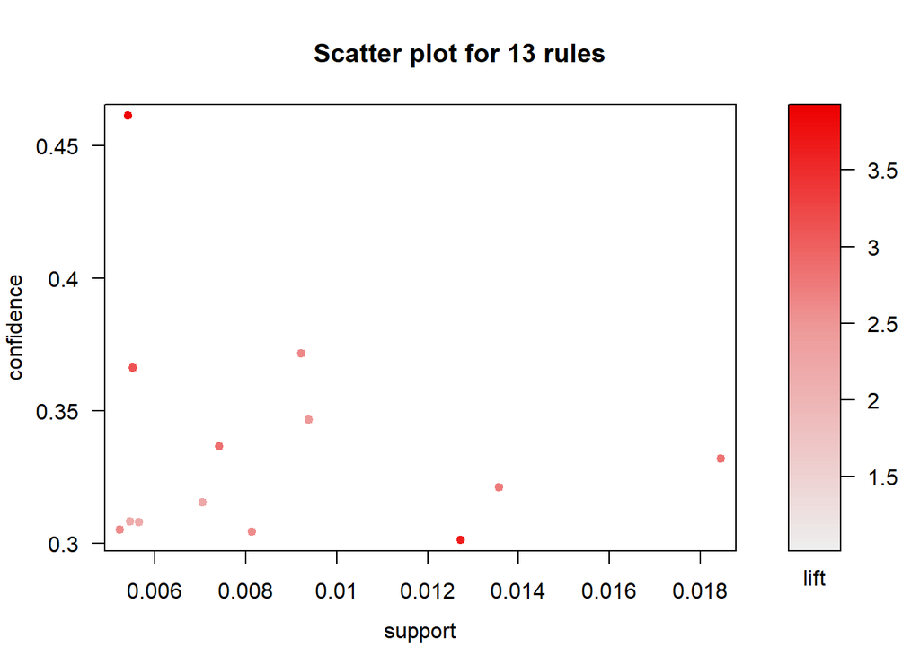

```r
plot(basket_rules)
```

```r
inspectDT(basket_rules)
```

|  | LHS | RHS | support | confidence | coverage | lift | count |
| --- | --- | --- | --- | --- | --- | --- | --- |
| [1] | {Organic Navel Orange} | {Bag of Organic Bananas} | 0.00552549348372837 | 0.366161616161616 | 0.0150903132383202 | 3.10362181243964 | 725 |
| [2] | {Blueberries} | {Banana} | 0.00545690115082692 | 0.308222126560482 | 0.0177044432588979 | 2.15966171237856 | 716 |
| [3] | {Apple Honeycrisp Organic} | {Bag of Organic Bananas} | 0.00523588141147778 | 0.3050621669627 | 0.0171633259660087 | 2.58573688160051 | 687 |
| [4] | {Cucumber Kirby} | {Banana} | 0.00566267814953129 | 0.307915457936179 | 0.0183903665879125 | 2.15751293580081 | 743 |
| [5] | {Organic Large Extra Fancy Fuji Apple} | {Bag of Organic Bananas} | 0.0074155933236796 | 0.336561743341404 | 0.022033381602012 | 2.85273038396807 | 973 |
| [6] | {Broccoli Crown} | {Banana} | 0.00704976754820517 | 0.315484311050477 | 0.0223458577852298 | 2.21054664386058 | 925 |
| [7] | {Organic Fuji Apple} | {Banana} | 0.0092218580900846 | 0.371507522259748 | 0.0248228031400046 | 2.6030920642797 | 1210 |
| [8] | {Honeycrisp Apple} | {Banana} | 0.00938190686685466 | 0.346662911855815 | 0.0270634860147855 | 2.42900996820472 | 1231 |
| [9] | {Organic Lemon} | {Bag of Organic Bananas} | 0.00813200213398369 | 0.304422253922967 | 0.0267129029799558 | 2.58031291584189 | 1067 |
| [10] | {Organic Raspberries} | {Organic Strawberries} | 0.0127276884383812 | 0.301117922827263 | 0.0422681198079415 | 3.62673789738986 | 1670 |

[output cut: 3 more lines]